# Untitled

2024 FALL

2025-03-13

[Source](https://www.kdnuggets.com/how-to-conduct-time-series-analysis-in-r)

```r
df_raw <- fread(here("1_data","clean","df_ili.csv"))
df <- df_raw %>% filter(REGION == "Alabama") %>% select(c("YEAR","WEEK","TOTAL PATIENTS"))
df$TEMP <- paste0(df$YEAR,"W",df$WEEK)
head(df)
```

```
##     YEAR  WEEK TOTAL PATIENTS    TEMP
##    <int> <int>         <char>  <char>
## 1:  2022    40          47154 2022W40
## 2:  2022    41          56751 2022W41
## 3:  2022    42          52144 2022W42
## 4:  2022    43          57545 2022W43
## 5:  2022    44          57949 2022W44
## 6:  2022    45          50267 2022W45
```

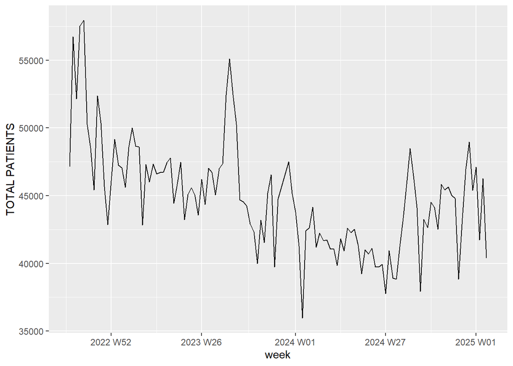

```r
df$`TOTAL PATIENTS` <- as.integer(df$`TOTAL PATIENTS`)
df <- df %>% mutate(week = yearweek(TEMP)) %>% select(-c("TEMP"))
ds <- df %>% as_tsibble(
  index = week,
  regular = TRUE
)

ds %>% ggplot(aes(x=week, y = `TOTAL PATIENTS`)) + geom_line()
```

```r
ts_data <- ts(ds$`TOTAL PATIENTS`)
```

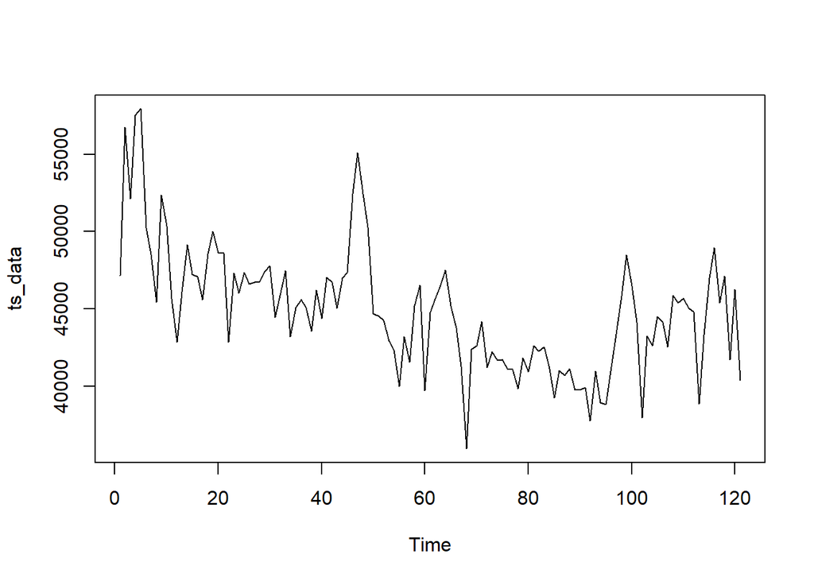

```r
plot(ts_data)
```

```r
fit <- auto.arima(ts_data)
```

## Autocorrelation Function (ACF)

- The Autocorrelation Function (ACF) measures how a time series is correlated with its past values. It helps identify patterns and lags in the data.
- It shows these correlations at different time lags.
- The ACF plot helps determine the Moving Average (MA) order (‘q’).

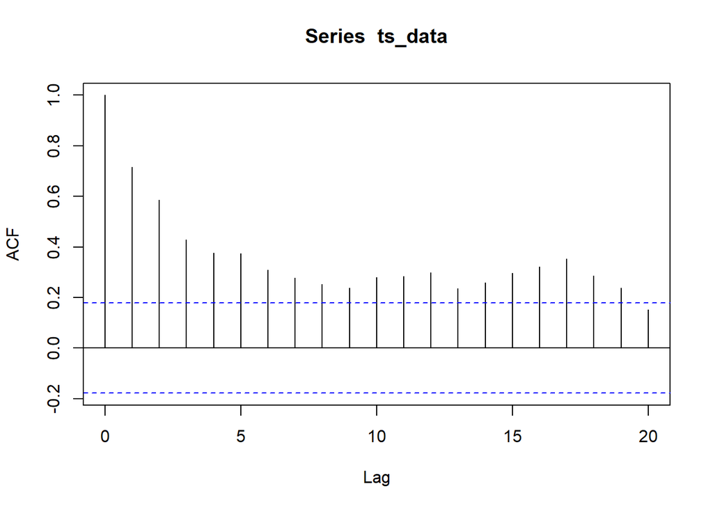

```r
acf(ts_data)
```

## Partial Autocorrelation Function (PACF)

- The Partial Autocorrelation Function (PACF) measures the correlation of a time series with its past values. - It excludes the effects of intervening lags.
  - It helps identify the strength of direct relationships at different lags.
  - The PACF plot displays these correlations for various time lags.
  - The PACF plot helps identify the Auto-Regressive (AR) order (‘p’).

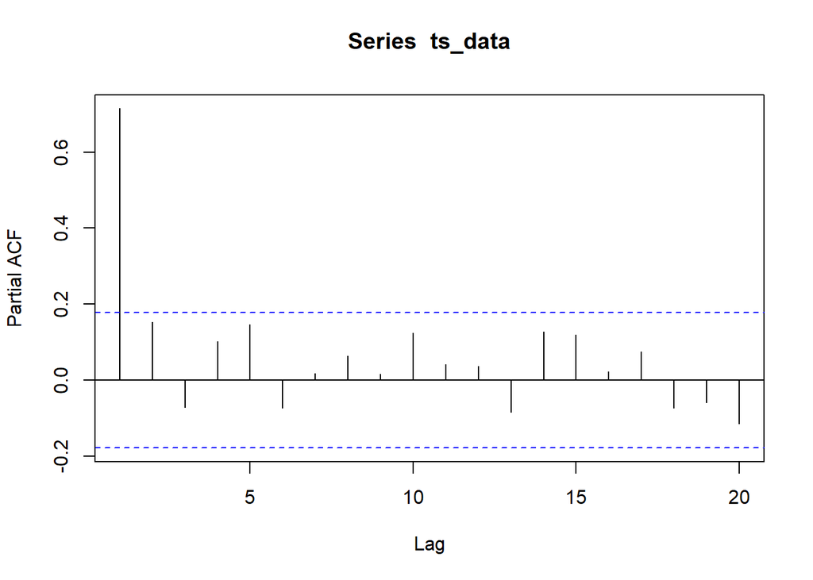

```r
pacf(ts_data)
```

## Ljung-Box Test

$$H_0: \text{The residuals are
independently distributed.}$$

$$H_A: \text{The residuals are not
independently distributed; they exhibit serial
correlation.}$$

- The Ljung-Box test checks for autocorrelation in the residuals of a time series model. It tests if the residuals are random.
- It tests for autocorrelation at multiple lags.
  - A low p-value suggests significant autocorrelation. This means the model might not be a good fit.

```r
Box.test(fit$residuals, lag = 20, type = "Ljung-Box")
```

```
##
##  Box-Ljung test
##
## data:  fit$residuals
## X-squared = 18.332, df = 20, p-value = 0.5655
```

## Residual Analysis

- Residual analysis examines the differences between the observed and predicted values from a time series model.
- It helps check if the model fits the data well.

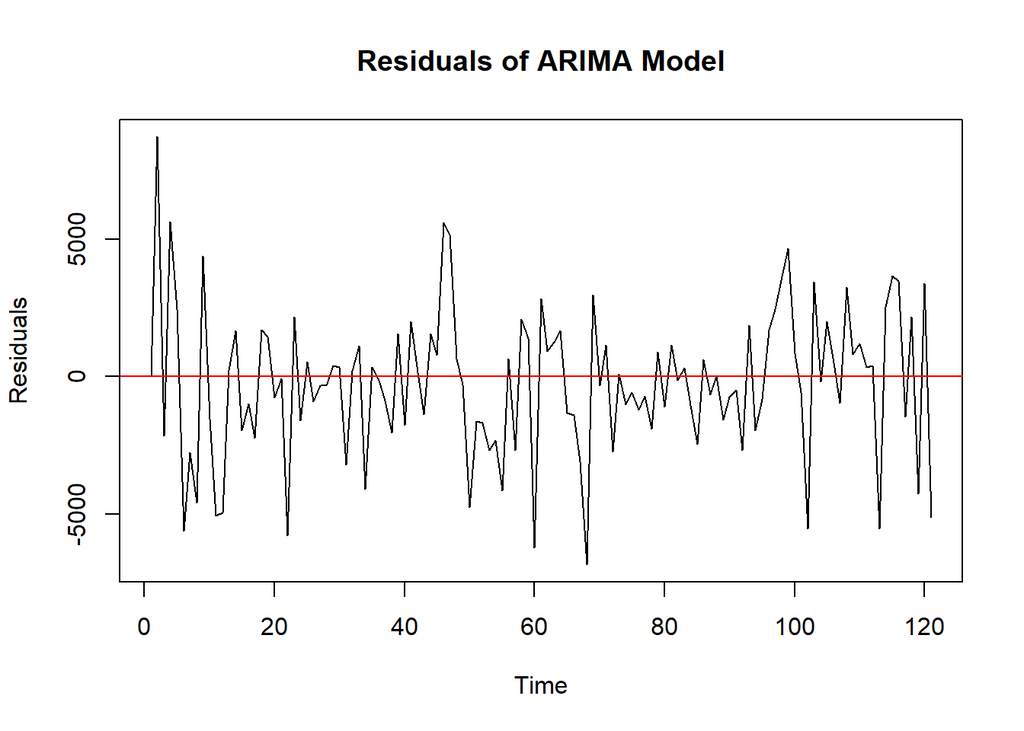

```r
plot (fit$residuals, main="Residuals of ARIMA Model", ylab="Residuals")
abline(h=0, col="red")
```

## Forecasting

- Forecasting involves predicting future values based on historical data. Use the ‘forecast’ to generate these predictions.

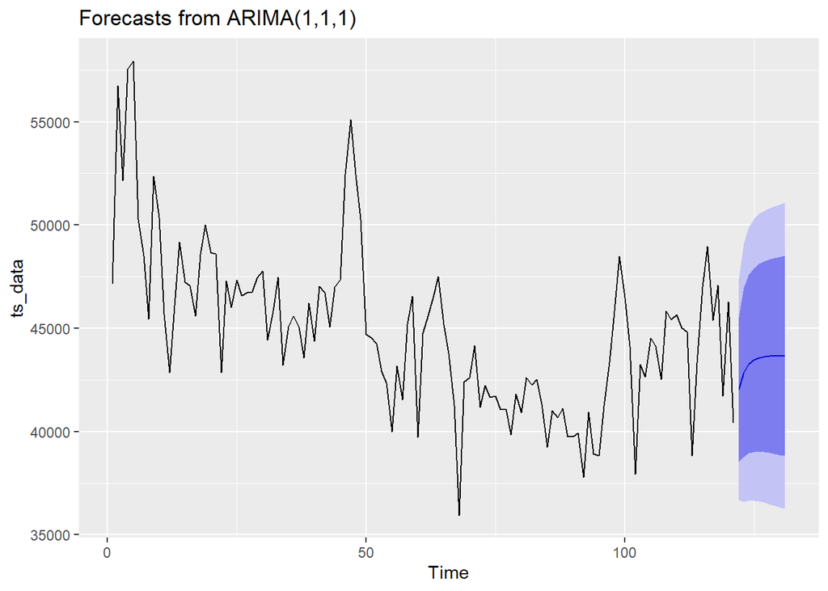

```r
forecast_result <- forecast (fit)

autoplot(forecast_result)
```

# using Fable

```r
fit <- ds %>%
  model(
    arima = ARIMA(`TOTAL PATIENTS`)
  )

fit %>% glance()
```

```
## # A tibble: 1 × 8
##   .model   sigma2 log_lik   AIC  AICc   BIC ar_roots  ma_roots
##   <chr>     <dbl>   <dbl> <dbl> <dbl> <dbl> <list>    <list>
## 1 arima  7518640.  -1119. 2246. 2247. 2257. <cpl [2]> <cpl [1]>
```